```python
from functools import partial, lru_cache
from itertools import product
import math

from matplotlib import pyplot as plt
import numpy as np
import pandas as pd
from scipy.stats import norm

plt.style.use("default.mplstyle")
plt.rcParams["lines.linewidth"] = 1
```

# 1

Let $X_1, \dots X_n \sim f$ and let $\hat{f}_n$ be the kernel density estimator using the boxcar kernel:

\begin{align*} K(x) = \begin{cases} 1 & -\frac12 < x < \frac12 \\ 0 & \text{otherwise.} \\ \end{cases} \\ \end{align*}

(a) Show that

$$\mathbb{E}(\hat{f}(x)) = \frac1h \int_{x - (h/2)}^{x + (h/2)}f(y) \, dy$$

and

$$\mathbb{V}(\hat{f}(x)) = \frac{1}{nh^2} \left[ \int_{x - (h/2)}^{x + (h/2)}f(y) \, dy - \left( \int_{x - (h/2)}^{x + (h/2)}f(y) \, dy\right)^2\right]$$

*Solution*:

\begin{align*} \hat{f}_n(x) &= \frac1n \sum_{i=1}^n \frac{1}{h} K \left( \frac{x - X_i}{h} \right) \\ &= \frac1n \sum_{i=1}^n \frac{1}{h} \mathbb{1}_{|(x-X_i)/h| \le 1/2} \\ &= \frac{1}{nh} C_x, \end{align*}

where $C_x$ is the number of $i$ such that $|x - X_i| \le h/2$. Observe:

\begin{align*} \mathbb{E}(C_x) &= \sum_{i=1}^n \mathbb{P}(|x - X_i| \le h/2) \\ &= \sum_{i=1}^n \int_{x - h/2}^{x + x/h} f(y)\, dy \\ &= n \int_{x - h/2}^{x + x/h} f(y)\, dy \end{align*}

Therefore

$$\mathbb{E}\left[\hat{f}_n(x)\right] = \frac{1}{h} \int_{x - h/2}^{x + h/2} f(y) \, dy.$$

For the variance, observe that $C_x \sim \text{Binom}(n, p)$, where $p = \int_{x - h/2}^{x + x/h} f(y)\, dy$. Then,

\begin{align*} \mathbb{V} \left( \hat{f}_n(x) \right) &= \frac{1}{n^2h^2} \mathbb{V}(C_x) \\ &= \frac{1}{nh^2} (p(1-p)) \\ &= \frac{1}{nh^2} \left[ \int_{x - (h/2)}^{x + (h/2)}f(y) \, dy - \left( \int_{x - (h/2)}^{x + (h/2)}f(y) \, dy\right)^2\right]. \end{align*}

(b) Show that if $h \to 0$ and $nh \to \infty$ as $n \to \infty$, then $\hat{f}_n(x) \to f(x)$ in probability.

*Solution*:

Observe that the bias tends to 0:

\begin{align*} \lim_{n\to\infty} \mathbb{E}[\hat{f}_n(x)] &= \lim_{n\to\infty} \frac{1}{h} \int_{x-(h/2)}^{x+(h/2)} f(y) \, dy \\ &= \lim_{h\to 0} \frac{1}{h} \int_{x-(h/2)}^{x+(h/2)} f(y) \, dy \\ &= \lim_{h\to 0} \frac{F(x + h/2) - F(x - h/2)}{h} \\ &= f(x). \tag{limit definition of derivative and continuity of $F$} \end{align*}

Thus, by the bias-variance decomposition: \begin{align*} 0 \le \lim_{n\to\infty} \mathbb{E}\left[ (\hat{f}_n(x) - f(x))^2 \right] &= 0 + \lim_{n\to\infty} \mathbb{V}\left[\hat{f}_n(x)\right] \\ &= \lim_{n\to\infty} \frac{1}{nh} \left[ \frac{1}{h}\int_{x - (h/2)}^{x + (h/2)}f(y) \, dy - \frac{1}{h}\left( \int_{x - (h/2)}^{x + (h/2)}f(y) \, dy\right)^2\right] \\ &\le \lim_{n\to\infty} \frac{1}{nh} \left[ \frac{1}{h}\int_{x - (h/2)}^{x + (h/2)}f(y) \, dy \right] = 0, \\ \end{align*}

where the last limit holds because \begin{align*} \lim_{n\to\infty}\frac{1}{h}\int_{x - (h/2)}^{x + (h/2)}f(y) \, dy = f(x) < \infty. \end{align*}

Thus $\hat{f}_n(x) \to f(x)$ in quadratic mean, and therefore also in probability.

# 2

Get the data on fragments of glass collected in forensic work from the book website. Estimate the density of the first variable (refractive index) using a histogram and use a kernel density estimator. Use cross-validation to choose the amount of smoothing. Experiment with different binwidths and bandwidths. Comment on the similarities and differences. Construct 95 percent confidence bands for your estimators.

*Solution*:

Getting the data:

```python
! curl -s --insecure https://www.stat.cmu.edu/~larry/all-of-statistics/=data/glass.dat --output data/glass.dat
glass_data = pd.read_csv("data/glass.dat", sep="\s+", usecols=["RI"])
refractive_indices = np.squeeze(glass_data.values)
```

Implementing a histogram estimator, including functions to compute estimated risk:

```python
class histogram_estimator:
    """
    Class for defining a histogram estimator, a nonparametric curve estimator.

    Attributes:
        X (list): List of values.
        m (int): Number of histogram bins.
        bounds (tuple): Lower and upper bounds (optional).

    Methods:
        cv_risk_estimate() -> Float:
            Computes the estimated risk using cross validation (up to a constant).

        simple_cv_risk_estimate() -> Float:
            Computes the estimated risk using cross validation (up to a constant) using simpler formula.
    """
    def __init__(self, X, m, bounds = None):
        self.X = X
        self.m = m
        if bounds is None:
            bounds = (X.min(), X.max())
        self.bounds = bounds
        self.n = len(self.X)
        self.counts, self.bin_edges = np.histogram(self.X,
                                                   bins=self.m,
                                                   range = self.bounds)
        self.h = self.bin_edges[1] - self.bin_edges[0]
        self.p_hat = self.counts / self.n

    def __call__(self, x):
        bin_index = min(math.floor((x - self.bin_edges[0]) // self.h) - 1, self.m - 1)
        density = self.counts[bin_index] / (self.h * self.n)
        return density

    def count_at(self, x):
        bin_index = min(math.floor((x - self.bin_edges[0]) // self.h), self.m - 1)
        return self.counts[bin_index]

    def plot(self, confidence_band=False, alpha=0.05, **kwargs):
        if confidence_band:
            xx = self.bin_edges[:-1]
            lower_bounds = [self.confidence_interval(x, alpha)[0] for x in xx]
            upper_bounds = [self.confidence_interval(x, alpha)[1] for x in xx]
            plt.step(xx, lower_bounds, "-", color='orange')
            plt.step(xx, upper_bounds, "-", color='orange')
            # plt.fill_between(xx, lower_bounds, upper_bounds, step="pre", alpha=0.1, color='', label="95% Confidence Envelope")
        plt.step(self.bin_edges[:-1] - self.h, [self(x) for x in self.bin_edges[0:-1]], label=f"hist (m={self.m})", **kwargs)

    def cv_risk_estimate(self):
        second_moment = np.sum((self.p_hat / self.h) ** 2 * self.h)
        sum = 0
        for index, value in enumerate(self.X):
            X_1 = np.delete(self.X, index)
            f = histogram_estimator(X_1, self.m, self.bounds)
            sum += f(value)
        return second_moment - (2 / self.n) * sum

    def simple_cv_risk_estimate(self):
        first_term = 2 / ((self.n - 1) * self.h)
        # note that the equation in the text has a typo
        second_term = ((self.n + 1) / (self.h * (self.n - 1))) * np.sum(self.p_hat ** 2)
        return first_term - second_term

    def confidence_interval(self, x, alpha):
        z = norm.ppf( 1 - (alpha / (2 * self.m)))
        c = (z / 2) * np.sqrt(self.m / self.n)
        l = (max(np.sqrt(self(x)) - c, 0)) ** 2
        u = (np.sqrt(self(x)) + c) ** 2
        return l, u
```

Computing the risk for various numbers of bins ($m$) from 1 to 1000. The minimizer is $m=106$, but the curve has is quite rough, and the risk is similar for values from ~50 to ~200.

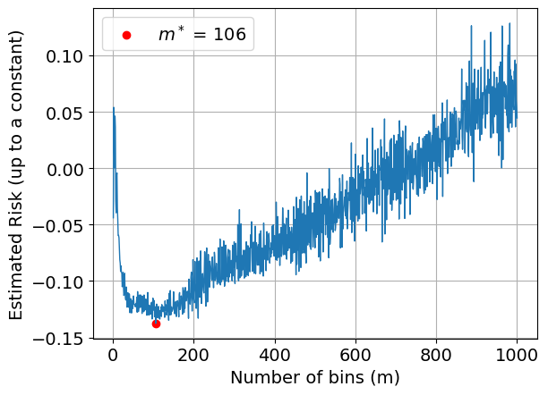

```python
mm = np.arange(1, 1001, 1)
risk = np.empty(shape=mm.size)

for index, m in enumerate(mm):
    est = histogram_estimator(refractive_indices, m)
    risk[index] = est.cv_risk_estimate()
m_star = mm[np.argmin(risk)]

plt.plot(mm, risk)
plt.scatter(x=m_star, y=risk.min(), color='red', label=f"$m^*$ = {m_star}")
plt.xlabel("Number of bins (m)")
plt.ylabel("Estimated Risk (up to a constant)")
plt.legend()
plt.show()
```

Plotting the optimal histogram along with the 95% confidence envelope. Since there are only 214 observations, and a range of values larger than 20, the envelope is large. This is unsurprising in light of Figure 20.4 in the text. In that plot of astronomy data, a similar number of bins is employed, but there are around five times more observations. Even so, there is substantial uncertainty.

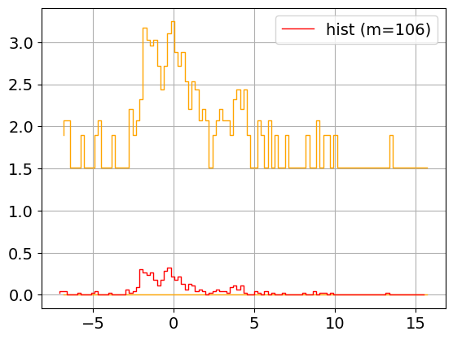

```python
optimal_hist = histogram_estimator(refractive_indices, m_star)
optimal_hist.plot(confidence_band=True, color='red', alpha=0.05)
plt.legend()
plt.show()
```

```python
def epanechnikov_kernel(x):
    cond = np.abs(x) < math.sqrt(5)
    return np.where(cond, (3 / 4) * (1 - (x ** 2) / 5) / math.sqrt(5), 0)

def gaussian_kernel(x):
    return norm.pdf(x)

class kde:
    def __init__(self, X, kernel, h):
        self.X = X
        self.K = kernel
        self.n = len(X)
        self.h = h

    def __call__(self, x):
        return (1 / (self.n * self.h) * np.sum(self.K((x - self.X) / self.h)))

    def plot(self, confidence_interval=False, **kwargs):
        X_min, X_max = (self.X.min(), self.X.max())
        xx = np.linspace(X_min, X_max, 1000)
        plt.plot(xx, [self(x) for x in xx],
                 label=f"K = {self.K.__name__.split('_')[0]}, h={self.h:.3f}",
                 **kwargs)
        if confidence_interval:
            bounds = [self.confidence_interval(x) for x in xx]
            lower_bounds = [bound[0] for bound in bounds]
            upper_bounds = [bound[1] for bound in bounds]
            plt.plot(xx, lower_bounds, color='orange')
            plt.plot(xx, upper_bounds, color='orange')

    def est_risk(self):
        if self.K.__name__ == "gaussian_kernel":
            K_2 = partial(norm.pdf, scale=np.sqrt(2))
            K_star = lambda x: K_2(x) - 2 * self.K(x)
            K_star_inputs = [(self.X[i] - self.X[j]) / self.h for i, j in product(range(self.n), range(self.n))]
            sum = np.sum(K_star(K_star_inputs))
            return (1 / (self.h * (self.n ** 2))) * sum + (2 / (self.n * self.h)) * self.K(0)
        else:
            raise ValueError(f"Kernel must be gaussian.")

    def confidence_interval(self, x, alpha = 0.05):
        if self.K.__name__ == "gaussian_kernel":
            a = self.X.min()
            b = self.X.max()
            omega = 3 * self.h
            m = (b - a) / omega
            q = norm.ppf((1 + (1 - alpha) ** (1 / m)) / 2)

            Y =  (1 / self.h) * self.K((x - self.X) / self.h)
            Y_bar = np.mean(Y)
            s_2 = (1 / (self.n - 1)) * np.sum(np.power(Y - Y_bar, 2))
            se = np.sqrt(s_2) / math.sqrt(self.n)
            lower_bound = self(x) - q * se
            upper_bound = self(x) + q * se
            return lower_bound, upper_bound
        else:
            raise ValueError(f"Kernel must be gaussian.")
```

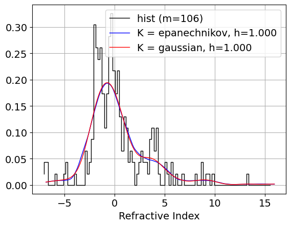

```python
hist_est = histogram_estimator(refractive_indices, m=m_star)
hist_est.plot(color='black')
est = kde(refractive_indices, epanechnikov_kernel, h=1)
est.plot(color='blue')
est = kde(refractive_indices, gaussian_kernel, h=1)
est.plot(color='red')
plt.legend()
plt.xlabel("Refractive Index")
plt.show()
```

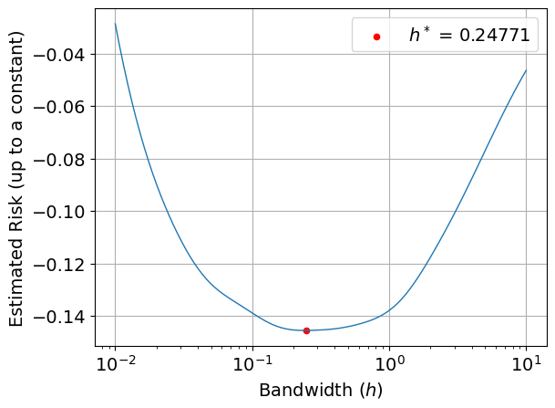

```python
hh = np.logspace(-2, 1, 100)
est_risks = np.empty(shape=len(hh))
for index, h in enumerate(hh):
    est = kde(refractive_indices, gaussian_kernel, h=h)
    est_risks[index] = est.est_risk()
plt.plot(hh, est_risks)
plt.xscale("log")
plt.xlabel("Bandwidth ($h$)")
plt.ylabel("Estimated Risk (up to a constant)")
h_star = hh[np.argmin(est_risks)]
plt.scatter(h_star, est_risks.min(), s=20, color='red', label=f"$h^*$ = {h_star:.5f}")
plt.legend()
plt.show()
```

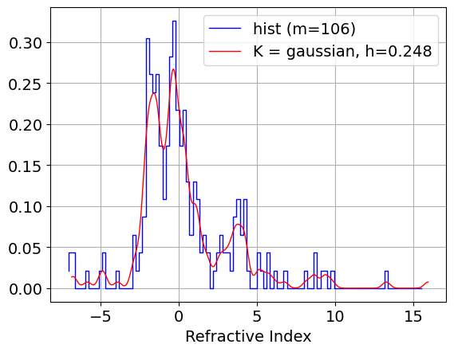

```python
hist_est = histogram_estimator(refractive_indices, m=m_star)
hist_est.plot(color='blue')
est = kde(refractive_indices, gaussian_kernel, h=h_star)
est.plot(color='red')
plt.legend()
plt.xlabel("Refractive Index")
plt.show()
```

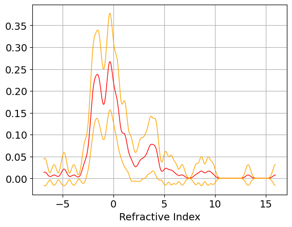

```python
est = kde(refractive_indices, gaussian_kernel, h=h_star)
est.plot(color='red', confidence_interval=True)
plt.xlabel("Refractive Index")
```

# 3

Consider the data from question 2. Let $Y$ be refractive index and let $x$ be aluminum content (the fourth variable). Perform a nonparametric regression to fit the model $Y = f(x) + \epsilon$. Use cross-validation to estimate the bandwidth. Construct 95 confidence bands for your estimate.

```python
data = pd.read_csv("data/glass.dat", sep="\s+")
refractive_indices = data["RI"].values
aluminum_content = data["Al"].values
```

```python
class NWRegressor:
    def __init__(self, x, Y, h):
        self.x = x
        self.Y = Y
        self.K = gaussian_kernel
        self.h = h
        self.n = len(self.x)

    def __call__(self, z):
        xx = np.repeat(self.x.reshape(-1,1), len(z), axis=1)
        K_values = self.K((z - xx) / self.h)
        W = K_values / np.sum(K_values, axis=0)
        return W.T @ self.Y

    def est_risk(self):
        xx = np.repeat(self.x.reshape(-1, 1), len(self.x), axis=1)
        K_values = self.K((xx - self.x) / h)
        K_values_sum = K_values.sum(axis=1)
        W = K_values / K_values_sum
        R = W.T @ self.Y
        terms = ((self.Y - R) / (1 - self.K(0) / K_values_sum)) ** 2
        if np.isnan(terms).any():
            return np.inf
        return np.sum(terms)

    def plot(self, confidence_bands=False, **kwargs):
        a = min(self.x)
        b = max(self.x)
        t = np.linspace(a, b, 1000)
        plt.plot(t, self(t), **kwargs)
        if confidence_bands:
            omega = 3 * self.h  # effective width of kernel
            m = (b - a) / omega
            alpha = 0.05
            q = norm.ppf((1 - (1 - alpha) ** (1 / m)) / 2)
            Y_sorted_by_x = np.array([z[1] for z in sorted(zip(self.x, self.Y), key=lambda x: x[0])])
            sigma_2_hat = (1 / (2 * (self.n - 1))) * np.sum(np.power(np.diff(Y_sorted_by_x), 2))
            sigma_hat = np.sqrt(sigma_2_hat)

            xx = np.repeat(self.x.reshape(-1, 1), len(t), axis=1)
            K_values = self.K((t - xx) / self.h)
            K_values_sum = K_values.sum(axis=0)
            W = K_values / K_values_sum
            se = sigma_hat * np.sqrt(np.sum(np.power(W, 2), axis=0))

            plt.plot(t, self(t) + q * se, color='orange')
            plt.plot(t, self(t) - q * se, color='orange')
```

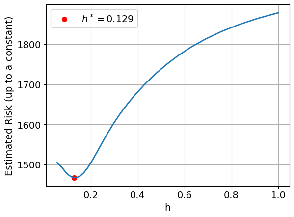

```python
h_vals = np.logspace(-4, 0, 100)
r_hats = []
for h in h_vals:
    r_hat = NWRegressor(aluminum_content, refractive_indices, h=h)
    r_hats.append(r_hat.est_risk())
h_star = h_vals[np.argmin(r_hats)]
fig = plt.figure()
plt.scatter(h_star, r_hats[np.argmin(r_hats)], s=50, color='red', label=f"$h^* =${h_star:.3f}")
plt.plot(h_vals, r_hats, linewidth=2)
plt.xlabel("h")
plt.ylabel("Estimated Risk (up to a constant)")
plt.legend()
plt.show()
```

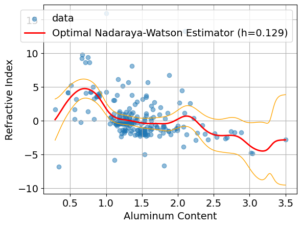

```python
r_hat = NWRegressor(aluminum_content, refractive_indices, h=h_star)
fig = plt.figure()
plt.scatter(aluminum_content, refractive_indices, alpha=0.5, label="data")
r_hat.plot(confidence_bands=True, color='red', linewidth=2, label=f"Optimal Nadaraya-Watson Estimator (h={r_hat.h:.3f})")
plt.xlabel("Aluminum Content")
plt.ylabel("Refractive Index")
plt.legend()
plt.show()
```

# 4

Prove Lemma 20.1:

The risk can be written as

$$R(f, \hat{f}) = \mathbb{E}\left(L(g, \hat{g})\right) = \int b^2(x) \, dx + \int v(x) \, dx$$

where

$$b(x) = \mathbb{E}(\hat{g}_n(x)) - g(x)$$

is the bias of $\hat{g}_n(x)$ at a fixed $x$ and

$$v(x) = \mathbb{V}(\hat{g}_n(x)) = \mathbb{E}\left[ \left(\hat{g}_n(x) - \mathbb{E}[\hat{g}_n(x)]\right)^2 \right]$$

is the variance of $\hat{g}_n(x)$ at a fixed $x$.

*Solution*:

\begin{align*} R(g, \hat{g}) &= \mathbb{E} \left[\int \left( g(x) - \hat{g}(x) \right)^2 \, dx \right] \\ &= \int \mathbb{E}\left[ \left( g(x) - \hat{g}(x) \right)^2 \right] \, dx \\ &= \int \left(\mathbb{E}\left[g(x) - \hat{g}(x) \right]\right)^2 + \mathbb{V}[g(x) - \hat{g}(x)] \, dx \tag{$E(X^2) = V(X) + E(X)^2$} \\ &= \int \left(g(x) - \mathbb{E}[\hat{g}(x)] \right)^2 + \mathbb{V}[\hat{g}(x)] \, dx \tag{$\mathbb{V}(-X + c) = \mathbb{V}(X)$} \\ &= \int b^2(x) \, dx + \int v(x) \, dx \end{align*}

# 5

Prove Theorem 20.3:

Consider fixed $x$ and fixed $m$, and let $B_j$ be the bin containing $x$. Then,

$$\mathbb{E}(\hat{f}_n(x)) = \frac{p_j}{h} \text{ and } \mathbb{V}(\hat{f}_n(x)) = \frac{p_j(1-p_j)}{nh^2}$$

*Solution*:

Note that $\nu_j$, the count of observations in $B_j$, is distributed as $\text{Binom}(n, p_j)$, and thus, $\mathbb{E}[\nu_j] = np_j$, and $\mathbb{V}[\nu_j] = np_j(1-p_j)$. Therefore,

\begin{align*} \mathbb{E}[\hat{f}_n(x)] &= \mathbb{E}[\hat{p_j}/h] \\ &= \frac{\mathbb{E}[\nu_j]}{nh} \\ &= p_j / h \end{align*}

and

\begin{align*} \mathbb{V}[\hat{f}_n(x)] &= \mathbb{V}[\hat{p_j}/h] \\ &= \frac{\mathbb{V}[\nu_j]}{(nh)^2} \\ &= \frac{p_j(1-p_j)}{nh^2}. \end{align*}

# 6

Prove Theorem 20.7:

The following identity holds:

$$\hat{J}(h) = \frac{2}{(n-1)h} - \frac{n+1}{(n - 1)h} \sum_{j=1}^m \hat{p}_j^2.$$

*Solution*: Let $\nu_{j(i)} = \nu_j$ when $X_i \in B_j$. Observe that $\sum_{i=1}^n \nu_{j(i)} = \sum_{j=1}^m \nu_j^2$. \begin{align*} \hat{J}(h) &= \int \left(\hat{f}_n(x)\right)^2 \, dx - \frac{2}{n} \sum_{i=1}^n \hat{f}_{(-i)}(X_i) \\ &= \sum_{j=1}^m \int_{B_j} (\hat{p}_j / h)^2 \, dx - \frac{2}{n} \sum_{i=1}^n \frac{\nu_{j(i)} - 1}{(n-1)h} \\ &= \sum_{j=1}^m \frac{\nu_j^2}{n^2 h} + \frac{2}{(n-1)h} - \frac{2}{n(n-1)h}\sum_{i=1}^n \nu_{j(i)} \\ &= \frac{2}{(n-1)h} + \left[\frac{1}{h} - \frac{2n^2}{n(n-1)h} \right]\sum_{j=1}^m \frac{\nu_{j}^2}{n^2} \\ &= \frac{2}{(n-1)h} - \frac{n+1}{(n-1)h}\sum_{j=1}^m \hat{p}_j. \end{align*}

# 7

Prove Theorem 20.15:

For any $h > 0$,

$$\mathbb{E}\left[\hat{J}(h)\right] = \mathbb{E}[J(h)].$$

Also,

$$\hat{J}(h) \approx \frac{1}{hn^2}\sum_i \sum_j K^* \left( \frac{X_i - X_j}{h}\right) + \frac{2}{nh}K(0)$$

where $K^*(x) = K^{(2)}(x) - 2K(x)$ and $K^{(2)}(z) = \int K(z-y)K(y)\,dy$. In particular, if $K$ is a $N(0,1)$ Gaussian kernel then $K^{(2)}(z)$ is the $N(0,2)$ density.

*Solution*:

First, we demonstrate $\mathbb{E}\left[\hat{J}(h)\right] = \mathbb{E}[J(h)]$. Recalling:

$$J(h) = \int \hat{f}_n^2(x) \, dx - 2 \int \hat{f}_n(x) f(x) \, dx$$

and

$$\hat{J}(h) = \int \hat{f}^2(x) \, dx - \frac{2}{n} \sum_{i=1}^n \hat{f}_{-i}(X_i),$$

we may observe that it suffices to show

$$\mathbb{E}\left[\int \hat{f}_n(x) f(x) \, dx \right] = \mathbb{E}\left[ \frac{1}{n} \sum_{i=1}^n \hat{f}_{-i}(X_i) \right].$$

Observing:

$$\mathbb{E}\left[\hat{f}_{-i}(X_i)\right] = \int \frac{1}{h} K\left( \frac{X_i - u}{h}\right) f(u)\, du,$$

we have

$$ \begin{align*} \frac{1}{n}\mathbb{E}\left[\sum_{i=1}^n\hat{f}_{-i}(X_i)\right] &= \int \frac{1}{n}\sum_{i=1}^n K\left( \frac{X_i - u}{h}\right) f(u)\, du \\ &= \int \hat{f}_n(u) f(u) \, du. \end{align*} $$

We now derive the formula. Assume the kernel is even.

\begin{align*} \int \hat{f}^2(x) \, dx &= \int \left( \frac{1}{n} \sum_{i=1}^n \frac{1}{h} K \left(\frac{x - X_i}{h}\right) \right) \left( \frac{1}{n} \sum_{j=1}^n \frac{1}{h} K \left(\frac{x - X_j}{h}\right) \right) \, dx \\ &= \frac{1}{n^2h^2} \sum_{i=1}^n \sum_{j=1}^n \int K \left(\frac{x - X_i}{h}\right) K \left(\frac{x - X_j}{h}\right) \, dx \\ &= \frac{1}{n^2h} \sum_{i=1}^n \sum_{j=1}^n \int K(u) K \left(u + \frac{X_i - X_j}{h}\right) \, dy \tag{Letting $u = (x - X_i)/h$} \\ &= \frac{1}{n^2h} \sum_{i=1}^n \sum_{j=1}^n \int K \left(\frac{X_i - X_j}{h} - y\right) K(y) \, dy \tag{Letting $y = -u$} \\ &= \frac{1}{n^2h} \sum_{i=1}^n \sum_{j=1}^n K^{(2)}\left(\frac{X_i - X_j}{h}\right) \tag{1} \end{align*}

\begin{align*} \hat{f}_{-i}(X_i) &= \frac{1}{(n-1)h}\sum_{j=1, j\ne i}^n K \left(\frac{X_i - X_j}{h}\right) \\ \Rightarrow \sum_{i=1}^n \hat{f}_{-i}(X_i) &= \frac{1}{(n-1)h} \sum_{i=1}^n \sum_{j=1, j\ne i}^n K \left(\frac{X_i - X_j}{h}\right) \\ &\approx \frac{1}{nh} \sum_{i=1}^n \sum_{j=1, j\ne i}^n K \left(\frac{X_i - X_j}{h}\right) \tag{$n \approx n-1$}\\ &= \frac{1}{nh} \sum_{i=1}^n \sum_{j=1}^n K \left(\frac{X_i - X_j}{h}\right) - \frac{1}{h}K(0) \\ \Rightarrow -\frac{2}{n}\sum_{i=1}^n \hat{f}_{-i}(X_i) &= -\frac{2}{n^2h}\sum_{i=1}^n \sum_{j=1}^n K \left(\frac{X_i - X_j}{h}\right) + \frac{2}{nh}K(0) \tag{2} \end{align*}

The formula follows from summing (1) and (2). Suppose $K$ is a $N(0,1)$ Gaussian kernel. Then,

\begin{align*} K^{(2)}(z) &= \int K(z-y)K(y) \, dy \\ &= \frac{1}{2\pi} \int e^{-(z-y)^2 / 2} e^{-y^2 / 2} \, dy \\ &= \frac{1}{2\pi} \int e^{-z^2 / 2 + zy - y^2 + (z^2 / 4 - z^2 / 4)} \, dy \tag{completing the square} \\ &= \frac{1}{2\pi} e^{-z^2 / 4} \int e^{-(y - z/2)^2} \, dy \\ &= \frac{1}{2\pi} e^{-z^2 / 4} (\sqrt{\pi}) \\ &= \frac{1}{\sqrt{2\pi\cdot 2}} e^{-\frac{1}{2}(z^2/2)}, \end{align*}

so $K^{(2)}(z)$ is the $N(0,2)$ Gaussian kernel.

# 8

Consider regression data $(x_1, Y_1), \dots (x_n, Y_n)$. Suppose that $0 \le x_i \le 1$ for all $i$. Define bins $B_j$ as in equation (20.7). For $x \in B_j$ define

$$\hat{r}_n(x) = \bar{Y}_j$$

where $\bar{Y}_j$ is the mean of the $Y_i$ corresponding to those $x_i$'s in $B_j$. Find the approximate risk of this estimator. From this expression for the risk, find the optimal bandwidth. At what rate does the risk go to zero?

*Solution*:

The following will be similar to the derivation of Theorem 20.4, which presents the risk as a function of $f$, $n$, and $h$ for a histogram estimator.

We have the bias-variance tradeoff:

\begin{align*} R(r, \hat{r}_n) &= \int \mathbb{V}\left[\hat{r}_n(x)\right] + \left(b(x)\right)^2 \, dx, \end{align*}

where $b(x) = \mathbb{E}[\hat{r}_n(x)] - r(x)$. We first compute the bias. Let $x \in B_j$. Observe $\mathbb{E}[\hat{r}(x)] = \frac{1}{h} \int_{B_j} r(u) \, du$, and that for $u \in B_j$

$$r(u) \approx r(x) + (u - x)r'(x).$$

Therefore,

\begin{align*} \mathbb{E}[\hat{r}(x)] &\approx \frac{1}{h} \int_{B_j} r(x) + (u - x)r'(x) \, du \\ &= r(x) + r'(x)\left(h\left(j - \frac{1}{2}\right) - x \right) \end{align*}

Thus,

$$b(x) \approx r'(x)\left(h\left(j - \frac{1}{2}\right) - x \right)$$

If $\tilde{x}_j$ is the center of the bin,

$$\int_{B_j} b^2(x) \, dx \approx (r'(\tilde{x}_j))^2 \frac{h^3}{12},$$

meaning

\begin{align*} \int_0^1 b^2(x)\, dx &= \sum_{j=1}^m \int_{B_j} b^2(x)\,dx \\ &\approx \frac{h^2}{12} \sum_{j=1}^m h(r'(\tilde{x}_j))^2 \\ &\approx \frac{h^2}{12} \int_0^1 (r'(x))^2 \, dx. \end{align*}

Assume that observations are evenly distributed in $[0,1]$. Observe that $\mathbb{V}[\hat{r}(x)] = \mathbb{V}[\bar{Y}_j] = \frac{1}{nh}\mathbb{V}[Y_j] = \frac{\sigma^2}{nh}$, and therefore

$$\int_0^1 \mathbb{V}[\hat{r}(x)] = \frac{\sigma^2}{nh}.$$

Altogether,

$$R(r, \hat{r}_n) = \frac{h^2}{12} \int_0^1 (r'(x))^2 \, dx + \frac{\sigma^2}{nh}, \tag{1}$$

which is minimized by

$$h^* = \left( \frac{6\sigma^2}{n \int_0^1 (r'(x))^2 \, dx} \right)^{1/3}.$$

Plugging $h^*$ into (1), we observe the risk goes to zero with $n^{-2/3}$.

# 9

Show that with suitable smoothness assumptions on $r(x)$, $\hat{\sigma}^2$ in equation (20.36) is a consistent estimator of $\sigma^2$.

*Solution*:

Recall

$$\hat{\sigma}^2 = \frac{1}{2(n-1)}\sum_{i=1}^{n-1}(Y_{i+1} - Y_i)^2.$$

Since $X_n \xrightarrow{qm} X \Rightarrow X_n \xrightarrow{p} X$, it suffices to show convergence in quadratic mean. Thus, by Chapter 5, #2, it suffices to show $\mathbb{V}[\hat{\sigma}^2] \to 0$ and $\mathbb{E}[\hat{\sigma}^2] \to \sigma^2$.

First showing $\mathbb{E}[\hat{\sigma}^2] \to \sigma^2$. Observe:

\begin{align*} Y_{i+1} - Y_i &= \left[r(x_{i+1}) + \epsilon_{i+1}\right] - \left[r(x_i) + \epsilon_i \right] \\ &= \left[r(x_{i+1}) - r(x_i)\right] + \left[\epsilon_{i+1} - \epsilon_i \right] \\ &\Rightarrow \mathbb{V}[Y_{i+1} - Y_i] = \mathbb{V}[\epsilon_{i+1} - \epsilon_i] \tag{$x_j$ is fixed for all $j$} = 2\sigma^2\\ \end{align*}

Suppose $r$ is Lipschitz continuous with constant $L$. That is, $r(x_{i+1}) - r(x_i) \le L(x_{i+1} - x_i)$. Observe:

$$0 \le [r(x_{i+1}) - r(x_i)]^2 \le L^2(x_{i+1} - x_i)^2$$

Therefore, \begin{align*} \mathbb{E}[(Y_{i+1} - Y_i)^2] &= \mathbb{V}[Y_{i+1} - Y_i] + \left(\mathbb{E}[Y_{i+1} - Y_i]\right)^2 \\ &= 2\sigma^2 +[r(x_{i+1}) - r(x_i)]^2 \in [2\sigma^2, 2\sigma^2 + L^2(x_{i+1} - x_i)^2] \end{align*}

and thus

\begin{align*} \mathbb{E}[\hat{\sigma}^2] &= \frac{1}{2(n-1)}\sum_{i=1}^{n-1}\mathbb{E}\left[(Y_{i+1} - Y_i)^2\right] \\ &\in [\sigma^2, \sigma^2 + \frac{L^2}{2(n-1)}\sum_{i=1}^{n-1}(x_{i+1} - x_i)^2]. \end{align*}

Assume the domain of the $x$ values is a finite interval of width $M$. The term $\sum_{i=1}^{n-1}(x_{i+1} - x_i)^2$ assumes the greatest value when the $x_j$ terms are evenly distributed (this can be shown using, e.g., the method of Lagrange multipliers). Furthermore, in that case, $\sum_{i=1}^{n-1}(x_{i+1} - x_i)^2 = \sum_{i=1}^{n-1}(M/(n-1))^2 = M^2 / (n-1)$. Therefore,

$$0 \le \frac{L^2}{2(n-1)}\sum_{i=1}^{n-1}(x_{i+1} - x_i)^2 \le \frac{(LM)^2}{2(n-1)^2} \to 0$$

and thus

$$\mathbb{E}[\hat{\sigma}^2] \to \sigma^2.$$

We now show $\mathbb{V}[\hat{\sigma}^2] \to 0$. Observe

\begin{align*} \mathbb{V}[(Y_{i+1} - Y_i)^2] &= \mathbb{E}[(Y_{i+1} - Y_i)^4] - \mathbb{E}[(Y_{i+1} - Y_i)^2]^2 \\ \end{align*}

Denoting $r_i = r(x_i)$, we can expand the first integrand:

\begin{align*} (Y_{i+1} - Y_i)^4 &= (r_{i+1} + \epsilon_{i+1} - r_i - \epsilon_i)^4 \\ &= (r_{i+1} - r_i)^4 + 4(r_{i+1} - r_i)^3(\epsilon_{i+1} - \epsilon_i) + 6(r_{i+1} - r_i)^2(\epsilon_{i+1} - \epsilon_i)^2 + 4(r_{i+1} - r_i)(\epsilon_{i+1} - \epsilon_i)^3 + (\epsilon_{i+1} - \epsilon_i)^4 \end{align*}

Note that

- $\mathbb{E}[\epsilon_{i+1} - \epsilon_i] = 0$
- $\mathbb{E}\left[(\epsilon_{i+1} - \epsilon_i)^2\right] = \mathbb{E}[\epsilon_{i+1}^2] - 2\mathbb{E}[\epsilon_{i+1}]\mathbb{E}[\epsilon_{i}] + \mathbb{E}[\epsilon_{i}^2] = \sigma^2 + 0 + \sigma^2 = 2\sigma^2$
- $\mathbb{E}\left[(\epsilon_{i+1} - \epsilon_i)^3\right] = \mathbb{E}[\epsilon_{i+1}^3] - 3\mathbb{E}[\epsilon_{i+1}^2]\mathbb{E}[[\epsilon_i] + 3\mathbb{E}[\epsilon_{i+1}]\mathbb{E}[[\epsilon_i^2] - \mathbb{E}[\epsilon_i^3] = 0 -3(\sigma^2)(0) + 3(0)(\sigma^2) - 0 = 0$
- $\mathbb{E}\left[(\epsilon_{i+1} - \epsilon_i)^4\right] = \mathbb{E}[\epsilon_{i+1}^4] - 4\mathbb{E}[\epsilon_{i+1}^3]\mathbb{E}[[\epsilon_i] + 6\mathbb{E}[\epsilon_{i+1}^2]\mathbb{E}[[\epsilon_i^2] - 4\mathbb{E}[\epsilon_i^1]\mathbb{E}[\epsilon_i^3] + \mathbb{E}[\epsilon_i^4] = 3\sigma^4 - 0 + 6\sigma^2 \sigma^2 - 0 + 3\sigma^4 = 12\sigma^4$

Hence,

\begin{align*} \mathbb{E}[(Y_{i+1} - Y_i)^4] = (r_{i+1} - r_i)^4 + 12\sigma^2(r_{i+1} - r_i)^2 + 12\sigma^4. \end{align*}

Recalling the Lipschitz continuity of $r$, we have

- $\mathbb{E}[(Y_{i+1} - Y_i)^4] \in [12\sigma^4, 12\sigma^4 + 12\sigma^2L^2(x_{i+1} - x_i)^2 + L^4(x_{i+1} - x_i)^4]$
- $\mathbb{E}[(Y_{i+1} - Y_i)^2]^2 \in [4\sigma^4, 4\sigma^4 + 2\sigma^2L^2(x_{i+1} - x_i)^2 + L^4(x_{i+1} - x_i)^4]$

So, we may bound the variance of $Y_{i+1} - Y_i$:

\begin{align*} 8\sigma^2 \le \mathbb{V}[(Y_{i+1} - Y_i)^2] \le 8\sigma^2 + 14\sigma^2L^2(x_{i+1} - x_i)^2 + 2L^4(x_{i+1} - x_i)^4 \end{align*}

and thus

\begin{align*} 0 \le \mathbb{V}[\hat{\sigma}^2] &= \frac{1}{4(n-1)^2}\sum_{i=1}^{n-1}\mathbb{V}[(Y_{i+1} - Y_i)^2] \\ &\le \frac{8(n-1)\sigma^2}{4(n-1)^2} + \frac{14L^2}{4(n-1)^2}\sum_{i=1}^{n-1}(x_{i+1} - x_i)^2 + \frac{2L^4}{4(n-1)^2}\sum_{i=1}^{n-1}(x_{i+1} - x_i)^4 \\ &\le \frac{2\sigma^2}{(n-1)} + \frac{7(LM)^2}{2(n-1)^3} + \frac{(LM)^4}{2(n-1)^5} \to 0.\\ \end{align*}

In summary, we have shown that in the case of a finite domain and Lipschitz continuity of the true regression function, $\hat{\sigma}^2$ is a consistent estimator.

# 10

Prove Theorem 20.22:

$\hat{J}$ can be written as

$$\hat{J}(h) = \sum_{i=1}^n (Y_i - \hat{r}(x_i))^2 \frac{1}{\left(1 - \frac{K(0)}{\sum_{j=1}^n K\left(\frac{x_i - x_j}{h}\right)} \right)^2}$$

*Solution*:

Recall:

\begin{align*} \hat{J}(h) = \sum_{i=1}^n (Y_i - \hat{r}_{-i}(x_i))^2 \end{align*}

We can express the evaluation at $x_i$ of the estimator trained without observation $i$ in the following way:

\begin{align*} \hat{r}_{-i}(x_i) &= \sum_{j=1, j\ne i}^n \frac{K((x_i - x_j)/h)}{\sum_{k=1, k\ne i}^n K((x_i - x_k)/h)}Y_j \\ &= \sum_{j=1, j\ne i}^n \frac{K((x_i - x_j)/h)}{\sum_{k=1}^n K((x_i - x_k)/h) - K(0)}Y_j \\ &= \frac{1}{\sum_{k=1}^n K((x_i - x_k)/h) - K(0)} \left[ \sum_{j=1}^n K((x_i - x_j)/h)Y_j - K(0)Y_i \right] \\ &= \frac{1}{1 - \frac{K(0)}{\sum_{k=1}^n K((x_i - x_k)/h)}}\left[\sum_{j=1}^n \frac{K((x_i - x_j)/h)Y_j}{\sum_{k=1}^n K((x_i - x_k)/h)} - \frac{K(0)Y_i}{\sum_{k=1}^n K((x_i - x_k)/h)} \right] \\ &= \frac{1}{1 - \alpha}\left[\hat{r}(x_i) - \alpha Y_i \right] \tag{$\alpha = \frac{K(0)}{\sum_{k=1}^n K((x_i - x_k)/h)}$} \\\ \end{align*}

Therefore,

\begin{align*} Y_i - \hat{r}_{-i}(x_i) &= Y_i - \frac{1}{1-\alpha}[\hat{r}(x_i) - \alpha Y_i] \\ &= \frac{(1-\alpha)Y_i - \hat{r}(x_i) + \alpha Y_i}{1-\alpha} \\ &= (Y_i - \hat{r}(x_i))\frac{1}{1-\alpha}, \end{align*}

and, finally:

\begin{align*} \sum_{i=1}^n (Y_i - \hat{r}_{-i}(x_i))^2 &= \sum_{i=1}^n (Y_i - \hat{r}(x_i))^2\frac{1}{(1-\alpha)^2} \\ &= \sum_{i=1}^n (Y_i - \hat{r}(x_i))^2 \frac{1}{\left(1 - \frac{K(0)}{\sum_{j=1}^n K\left(\frac{x_i - x_j}{h}\right)} \right)^2}. \end{align*}